# Decision Trees in R

Ruth Ogal

2025-03-26

First, we load all the packages needed to complete this analysis.

```r
library("rpart")
library("rpart.plot")
library("caret")
```

After loading the dataset in R, we subset it to form a new dataset called `white`, containing the first 11 columns of the original dataset and all rows having the `color` variable as `white`.

```r
df <- read.csv("C:/Users/User/Desktop/Decision_trees_Random_Forests/winequality-all.csv", comment.char="#")
# Create new dataset
white <- df[df$color == "white", 1:11]
```

The target variable, `alcohol', is the 11th variable of`white`. We convert it into a binary factor variable using the following code:

```r
white$alcohol <- factor(as.character(as.numeric(white$alcohol >= 12)))
table(white$alcohol)
```

```
   0    1
4085  813
```

Next, we split it into training (60%) and test (40%) sets.

```r
# Create a 60-40 split in the dataset
set.seed(123)
spt <- sample(1:nrow(white), round(nrow(white) * 0.6))
XY_train <- white[spt,]
XY_test <- white[-spt,]
```

## Build model

To build the decision tree, we use the `rpart()` from the package `rpart`.

After building the full tree, we prune it based on the value of the optimal $cp$. We can find this value by using the *1-SE rule*, which states that the best $cp$ value is that of the smallest tree within $1$ standard error of the minimum cross validation error, also called *xerror* in the *rpart* package.

*rpart()* automatically performs a 10-fold cross validation when building a decision tree model. This behavior is controlled by the *xval* parameter of the *rpart.control()* function in *rpart()*, which is set to $10$ by default.

```r
fita <- rpart(alcohol~., data=XY_train, method="class", control = rpart.control(cp = 0))
```

Call the summary() function on the fitted model to get the following information:

- A $cp$ table
- A variable importance table
- Tree node details, including node number, number of observations, $cp$ value, probabilities, and split criteria.

To prune the tree, we must find the optimal $cp$ value. To obtain this value, we take a look at the $cp$ table. The table can be obtained in the following ways:

- From *summary(model)*
- From *model$cptable*
- From *printcp(model)*

We want the smallest *xerror* in this table. We can find the index of this value by calling the *which.min()* function on the *xerror* column of *fita$cptable*, as shown below.

```r
which.min(fita$cptable[, 4])
```

```
7
7
```

From the 7th row, we find *xerror* $= 0.4657258$ and *xstd* $= 0.02941365$. So, the optimal decision tree is the smallest tree with an *xerror* $\le (0.4657258 + 0.02941365 = 0.4951395)$. The tree that meets this threshold has a $cp$ value of $0.013104839$.

Next, we use the *prune()* function to prune the full tree based on the optimal $cp$ value, as shown below.

```r
fitoptimal <- prune(fita, cp = 0.013104839)
```

We can also plot the pruned tree using *rpart.plot()*. See how simple it is!

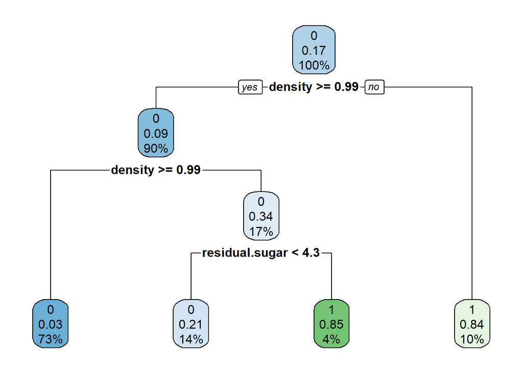

```r
rpart.plot(fitoptimal)
```

## Model Evaluation

Before we can use the model to make predictions on the train data, we determine a baseline accuracy score for the model. We set this score as the proportion of the majority class.

```r
round(nrow(XY_train[XY_train$alcohol == 0, ])/nrow(XY_train), 3)
```

```
[1] 0.831
```

By comparing this score with the model’s accuracy score, we can assess whether the model has learned meaningful patterns or performs worse than a naive model.

Next, we use the *predict()* function to make predictions on the train data.

```r
pred_train <- predict(fitoptimal, newdata = XY_train, type = "class")
```

We use the *confusionMatrix()* function from the *caret* package to compute a confusion matrix for evaluating the performance of the model on the training data.

```r
confusionMatrix(pred_train, XY_train$alcohol)
```

```
Confusion Matrix and Statistics

          Reference
Prediction    0    1
         0 2380  152
         1   63  344

               Accuracy : 0.9268
                 95% CI : (0.9168, 0.936)
    No Information Rate : 0.8312
    P-Value [Acc > NIR] : < 2.2e-16

                  Kappa : 0.7192

 Mcnemar's Test P-Value : 1.954e-09

            Sensitivity : 0.9742
            Specificity : 0.6935
         Pos Pred Value : 0.9400
         Neg Pred Value : 0.8452
             Prevalence : 0.8312
         Detection Rate : 0.8098
   Detection Prevalence : 0.8615
      Balanced Accuracy : 0.8339

       'Positive' Class : 0
```

From the confusion matrix, we see that the model’s training accuracy score is better than the baseline score

## References

Boehmke, Brad, and Brandon M. Greenwell. 2019. *Hands-on Machine Learning with r*. New York: CRC Press.